# Investigation of Global Temperatures From The Year 1875 to Present

# Project 1 Abstract

## Plot 1

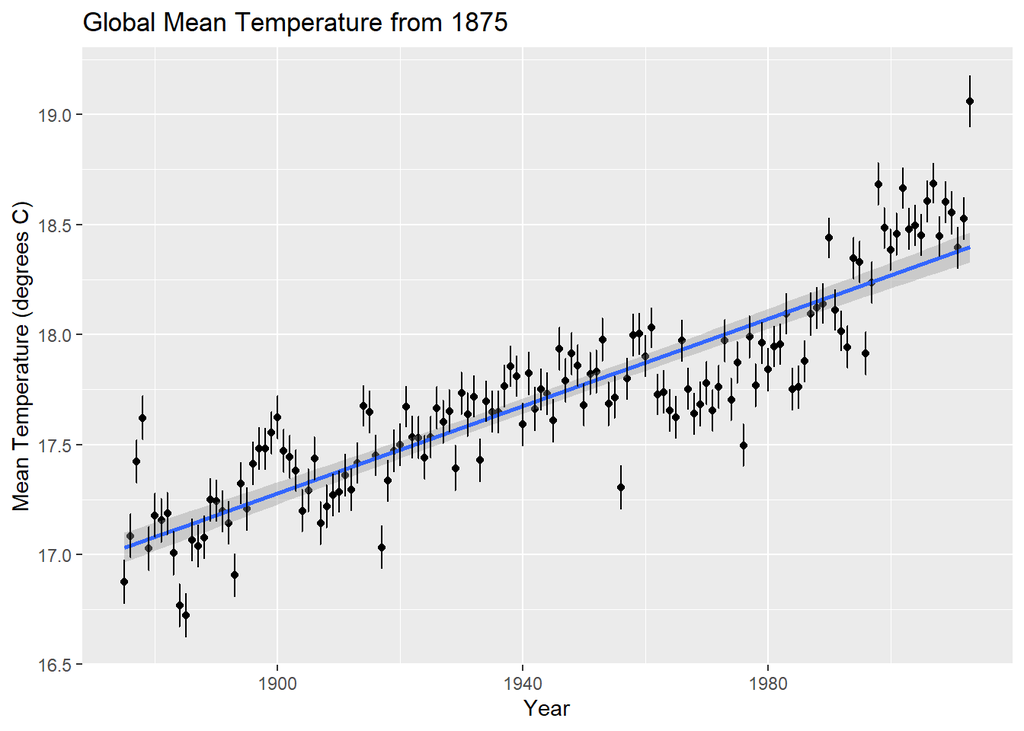

```r
library(tidyverse)

global <- read.csv(file.choose())
global$City <- as.factor(global$City)
global$Country <- as.factor(global$Country)


clean2 <- global %>%
  separate(dt, into = c("Year", "Month", "Day"), sep = "-") %>%
  select(-Day, -Month)

clean <- na.omit(clean2)

clean3 <- clean %>%
  select(Year, AverageTemperature)

clean4 <- clean3 %>%
  group_by(Year) %>%
  summarize(averageTemperature = mean(AverageTemperature, na.rm = T), sdTemperature = sd(AverageTemperature), SETemp = sdTemperature/sqrt(n()), tCrit = qt(0.975, n() - 1)) %>%
  filter(Year >= "1875") %>%
  mutate(MOE = tCrit * SETemp) %>%
  arrange(Year)

clean4$Year <- as.integer(clean4$Year)

ggplot(clean4, aes(x = Year, y = averageTemperature)) +
  geom_point() +
  geom_smooth(method = lm) +
  geom_errorbar(aes(ymin = averageTemperature - MOE, ymax = averageTemperature + MOE), width = 0.05) +
  labs(title = "Global Mean Temperature from 1875", x = "Year", y = "Mean Temperature (degrees C)")
```

```r
#lm(clean4$averageTemperature~clean4$Year)
```

### Analysis

Plot one demonstrates the average global temperatures since 1875. As is shown in the graph there is a steady increase in global temperatures since the year 1875. Specifically, the slope for plot 1 is 0.009894.This means that the average increase per year is 0.009894 degrees Celsius.

## Plot 2

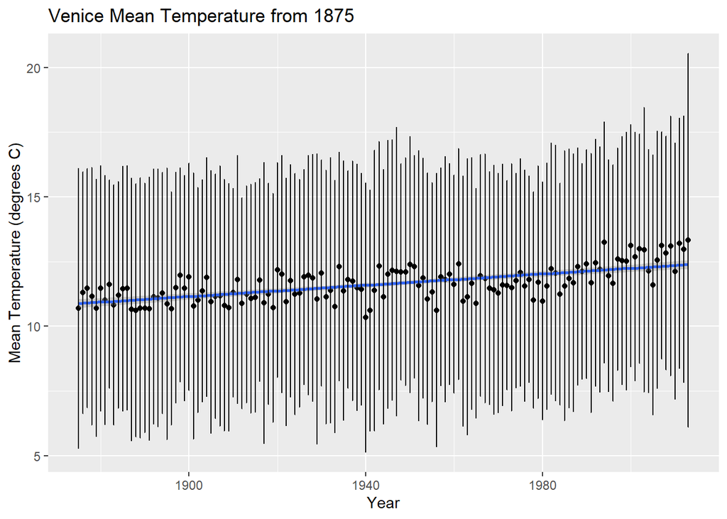

```r
clean$Year <- as.integer(clean$Year)

city <- clean %>%
  filter(City == "Venice") %>%
  filter(Year >= "1875") %>%
  group_by(Year) %>%
  summarize(averageTemperature = mean(AverageTemperature, na.rm = T), sdTemperature = sd(AverageTemperature), SETemp = sdTemperature/sqrt(n()), tCrit = qt(0.975, n() - 1)) %>%
  mutate(MOE = tCrit * SETemp) %>%
  arrange(Year)


ggplot(city, aes(x = Year, y = averageTemperature)) +
  geom_point() +
  geom_smooth(method = lm) +
  geom_errorbar(data = city, aes(ymin = averageTemperature - MOE, ymax = averageTemperature + MOE), width = 0.05) +
  labs(title = "Venice Mean Temperature from 1875", x = "Year", y = "Mean Temperature (degrees C)")
```

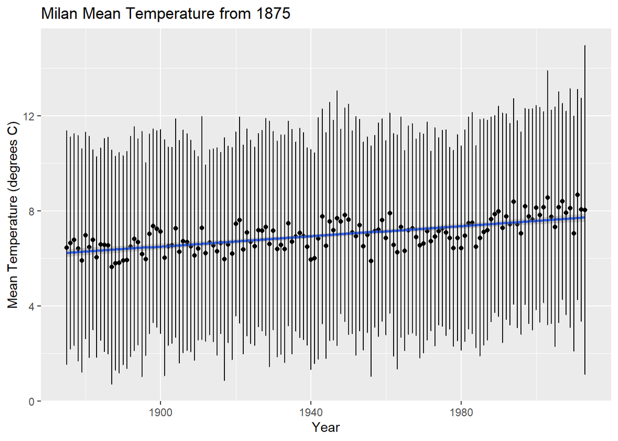

```r
#lm(city$averageTemperature~city$Year)
###City 2
city2 <- clean %>%
  filter(City == "Milan") %>%
  filter(Year >= "1875") %>%
  group_by(Year) %>%
  summarize(averageTemperature = mean(AverageTemperature, na.rm = T), sdTemperature = sd(AverageTemperature), SETemp = sdTemperature/sqrt(n()), tCrit = qt(0.975, n() - 1)) %>%
  mutate(MOE = tCrit * SETemp) %>%
  arrange(Year)

ggplot(city2, aes(x = Year, y = averageTemperature)) +
  geom_point() +
  geom_smooth(method = lm) +
  geom_errorbar(data = city2, aes(ymin = averageTemperature - MOE, ymax = averageTemperature + MOE), width = 0.05) +
  labs(title = "Milan Mean Temperature from 1875", x = "Year", y = "Mean Temperature (degrees C)")
```

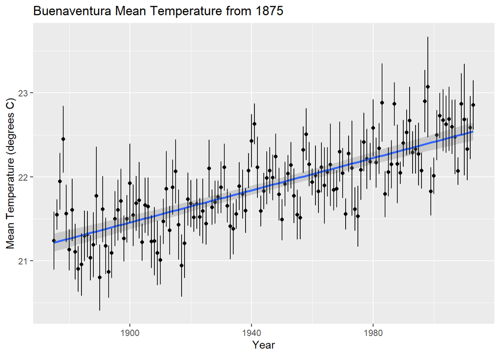

```r
#lm(city2$averageTemperature~city2$Year)
## 0.01074 is slope
### city 3
city3 <- clean %>%
  filter(City == "Buenaventura") %>%
  filter(Year >= "1875") %>%
  group_by(Year) %>%
  summarize(averageTemperature = mean(AverageTemperature, na.rm = T), sdTemperature = sd(AverageTemperature), SETemp = sdTemperature/sqrt(n()), tCrit = qt(0.975, n() - 1)) %>%
  mutate(MOE = tCrit * SETemp) %>%
  arrange(Year)

ggplot(city3, aes(x = Year, y = averageTemperature)) +
  geom_point() +
  geom_smooth(method = lm) +
  geom_errorbar(data = city3, aes(ymin = averageTemperature - MOE, ymax = averageTemperature + MOE), width = 0.05) +
  labs(title = "Buenaventura Mean Temperature from 1875", x = "Year", y = "Mean Temperature (degrees C)")
```

```r
#lm(city3$averageTemperature~city3$Year)
#0.009612
```

### Analysis

These plots show average change in mean for the cities of Venice, Milan, and Buenaventura. Even when investigating specific cities there is still an evident increase in temperature over the years. The slope for the city of Venice had an average increase of 0.01091 degrees Celsius every year. The slope for the city of Milan had and average increase of 0.01074 degrees Celsius every year. The city of Buenaventura, Columbia had an average increase of 0.009612 degrees every year. Columbia is much closer to the equator than Italy is so it would be interesting to see if there is a correlation between latitude and the average increase every year in degrees Celsius. It should also be mentioned that the average temperatures in Columbia are higher, more than likely due to the fact that Columbia is closer to the equator. This would mean that it would have higher temperatures for most of the year. Both Milan and Italy have similar average temperatures with Milan being colder on average. The error bars are also noticeably bigger for the city graphs vs the global graph. This is likely due to the fact that the global data is sampling all of the cities for every year, giving us a much smaller SE which ends up giving us a smaller MOE; while the city graphs only sample from their own city so the SE will be larger.

## Plot 3

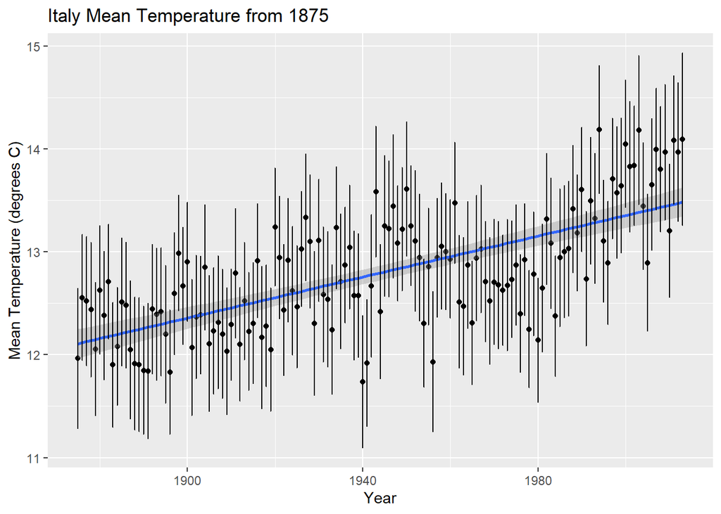

```r
country <- clean %>%
  filter(Country == "Italy") %>%
  filter(Year >= "1875") %>%
  group_by(Year) %>%
  summarize(averageTemperature = mean(AverageTemperature, na.rm = T), sdTemperature = sd(AverageTemperature), SETemp = sdTemperature/sqrt(n()), tCrit = qt(0.975, n() - 1)) %>%
  mutate(MOE = tCrit * SETemp) %>%
  arrange(Year)

ggplot(country, aes(x = Year, y = averageTemperature)) +
  geom_point() +
  geom_smooth(method = lm) +
  geom_errorbar(data = country, aes(ymin = averageTemperature - MOE, ymax = averageTemperature + MOE), width = 0.05) +
  labs(title = "Italy Mean Temperature from 1875", x = "Year", y = "Mean Temperature (degrees C)")
```

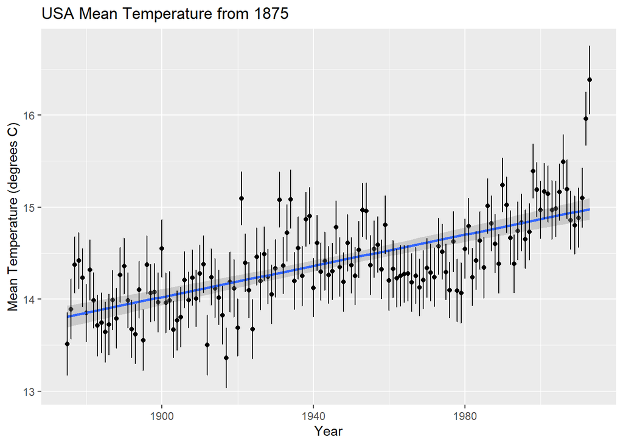

```r
#lm(country$averageTemperature~country$Year)
# 0.009968 is slope

###country 2

country2 <- clean %>%
  filter(Country == "United States") %>%
  filter(Year >= "1875") %>%
  group_by(Year) %>%
  summarize(averageTemperature = mean(AverageTemperature, na.rm = T), sdTemperature = sd(AverageTemperature), SETemp = sdTemperature/sqrt(n()), tCrit = qt(0.975, n() - 1)) %>%
  mutate(MOE = tCrit * SETemp) %>%
  arrange(Year)

ggplot(country2, aes(x = Year, y = averageTemperature)) +
  geom_point() +
  geom_smooth(method = lm) +
  geom_errorbar(data = country2, aes(ymin = averageTemperature - MOE, ymax = averageTemperature + MOE), width = 0.05) +
  labs(title = "USA Mean Temperature from 1875", x = "Year", y = "Mean Temperature (degrees C)")
```

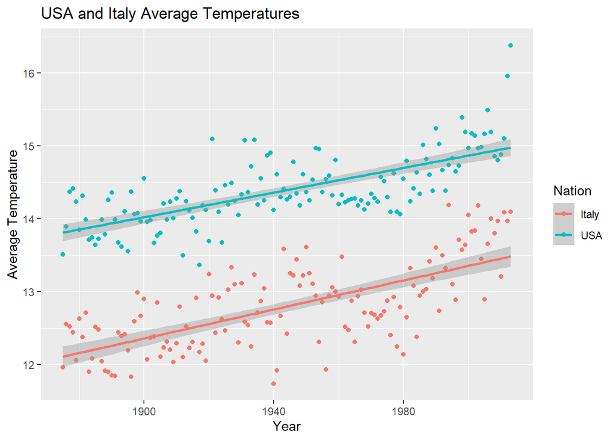

```r
#lm(country2$averageTemperature~country2$Year)
# 0.008466 is slope

countryUSA <- country2 %>%
  add_column(Nation = "USA")

countryItaly<- country %>%
  add_column(Nation = "Italy")

bothCountries <- rbind(countryUSA, countryItaly)
bothCountries$Nation <- as.factor(bothCountries$Nation)

ggplot(data = bothCountries, aes(Year, averageTemperature, col = Nation)) +
  geom_point() +
  geom_smooth(method = lm) +
  labs(title = "USA and Italy Average Temperatures", x = "Year", y = "Average Temperature" )
```

### Analysis

These plots show the average increase in temperature for the countries of Italy and USA. USA and Italy were chosen because they have similar latitudes and a correlation between latitudes and the slope of the average change in degrees Celsius over the years was being investigated. The average change in degrees Celsius was 0.009968 for Italy and 0.008466 for the US. USA had a slightly higher average temperature more than likely because USA also stretches lower than Italy. There are also many different biomes in USA that it could also affect the average temperature. The error bars are also noticeably larger for Italy. This is likely because Italy has less cities than the US in this dataset making a larger SE.

## Part 2

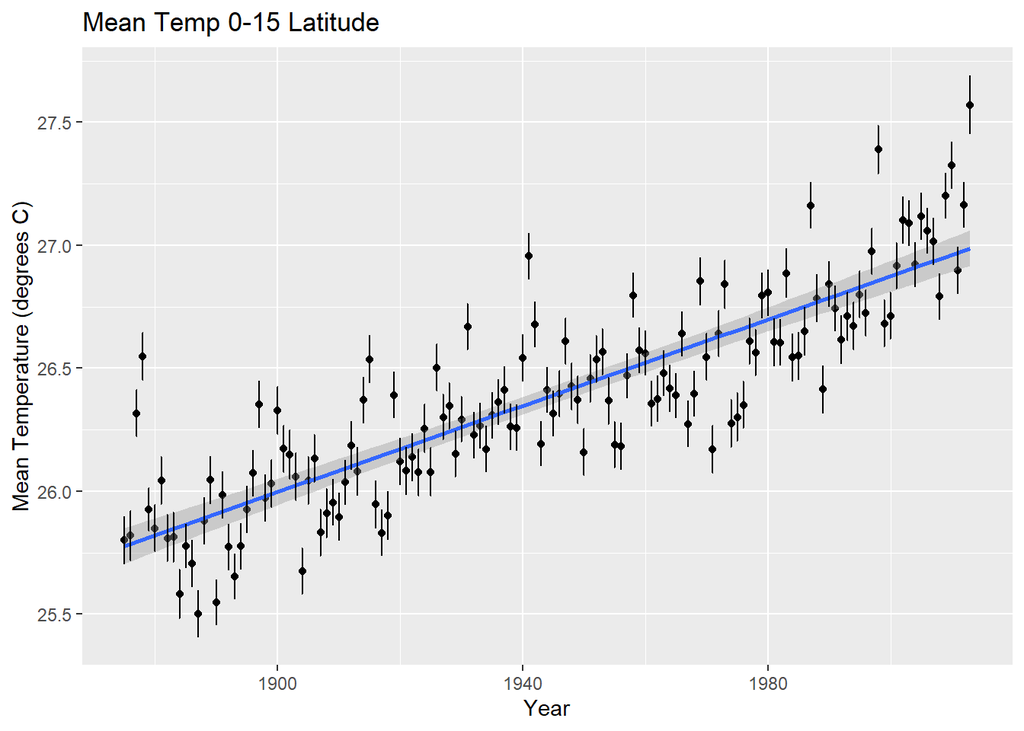

```r
cool <- clean %>%
  filter(Year >= 1875) %>%
  select(Year, AverageTemperature, Latitude) %>%
  filter(grepl('N', Latitude)) %>%
  mutate(northernLatitude = gsub('N', '',Latitude))

cool$northernLatitude <- as.numeric(cool$northernLatitude)

lat15 <- cool %>%
  filter(Latitude <= 15.0 & Latitude > 0.0) %>%
  group_by(Year) %>%
  summarize(averageTemperature = mean(AverageTemperature, na.rm = T), sdTemperature = sd(AverageTemperature), SETemp = sdTemperature/sqrt(n()), tCrit = qt(0.975, n() - 1)) %>%
  mutate(MOE = tCrit * SETemp) %>%
  arrange(Year) %>%
  add_column(Latitude = "0-15")



lat30 <- cool %>%
  filter(Latitude <= 30.0 & Latitude > 15.0) %>%
  group_by(Year) %>%
  summarize(averageTemperature = mean(AverageTemperature, na.rm = T), sdTemperature = sd(AverageTemperature), SETemp = sdTemperature/sqrt(n()), tCrit = qt(0.975, n() - 1)) %>%
  mutate(MOE = tCrit * SETemp) %>%
  arrange(Year) %>%
  add_column(Latitude = "15-30")


lat45 <- cool %>%
  filter(Latitude <= 45.0 & Latitude > 30.0) %>%
  group_by(Year) %>%
  summarize(averageTemperature = mean(AverageTemperature, na.rm = T), sdTemperature = sd(AverageTemperature), SETemp = sdTemperature/sqrt(n()), tCrit = qt(0.975, n() - 1)) %>%
  mutate(MOE = tCrit * SETemp) %>%
  arrange(Year) %>%
  add_column(Latitude = "30-45")


lat60 <- cool %>%
  filter(Latitude <= 60.0 & Latitude > 45.0) %>%
  group_by(Year) %>%
  summarize(averageTemperature = mean(AverageTemperature, na.rm = T), sdTemperature = sd(AverageTemperature), SETemp = sdTemperature/sqrt(n()), tCrit = qt(0.975, n() - 1)) %>%
  mutate(MOE = tCrit * SETemp) %>%
  arrange(Year) %>%
  add_column(Latitude = "45-60")


ggplot(lat15, aes(x = Year, y = averageTemperature)) +
  geom_point() +
  geom_smooth(method = lm) +
  geom_errorbar(data = lat15, aes(ymin = averageTemperature - MOE, ymax = averageTemperature + MOE), width = 0.05) +
  labs(title = "Mean Temp 0-15 Latitude", x = "Year", y = "Mean Temperature (degrees C)")
```

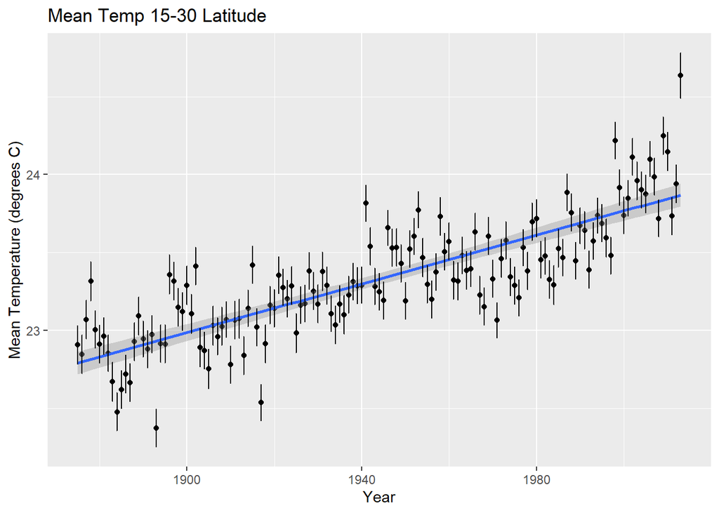

```r
#lm(lat15$averageTemperature~lat15$Year)
## 0.00877

ggplot(lat30, aes(x = Year, y = averageTemperature)) +
  geom_point() +
  geom_smooth(method = lm) +
  geom_errorbar(data = lat30, aes(ymin = averageTemperature - MOE, ymax = averageTemperature + MOE), width = 0.05) +
  labs(title = "Mean Temp 15-30 Latitude", x = "Year", y = "Mean Temperature (degrees C)")
```

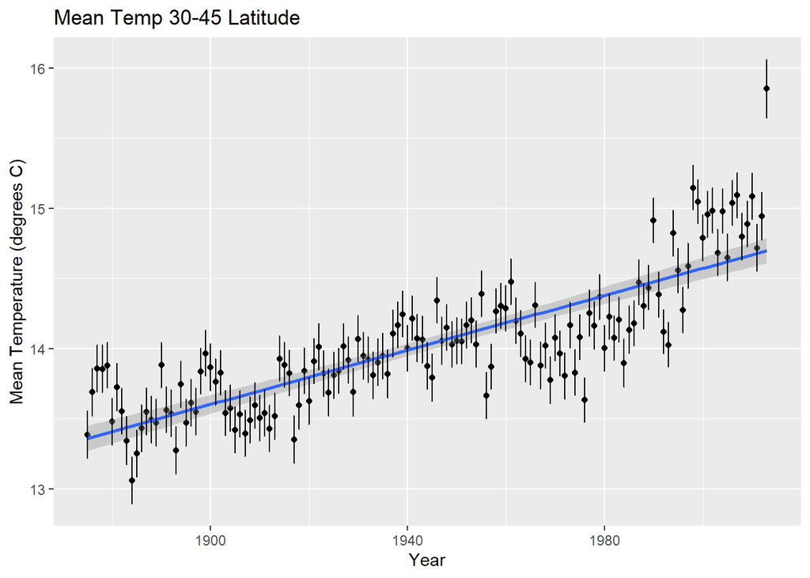

```r
#lm(lat30$averageTemperature~lat30$Year)
## 0.007806

ggplot(lat45, aes(x = Year, y = averageTemperature)) +
  geom_point() +
  geom_smooth(method = lm) +
  geom_errorbar(data = lat45, aes(ymin = averageTemperature - MOE, ymax = averageTemperature + MOE), width = 0.05) +
  labs(title = "Mean Temp 30-45 Latitude", x = "Year", y = "Mean Temperature (degrees C)")
```

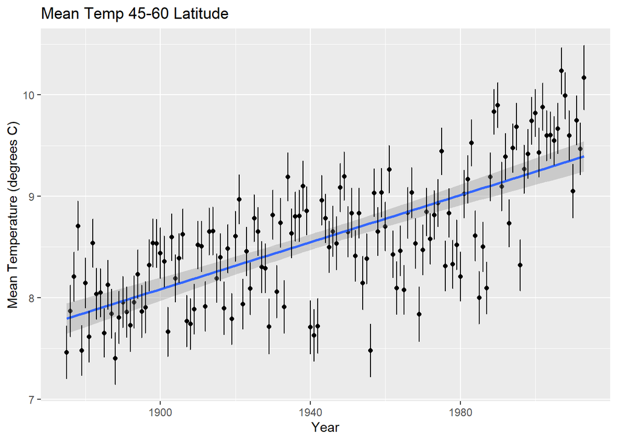

```r
#lm(lat45$averageTemperature~lat45$Year)
## 0.009701

ggplot(lat60, aes(x = Year, y = averageTemperature)) +
  geom_point() +
  geom_smooth(method = lm) +
  geom_errorbar(data = lat60, aes(ymin = averageTemperature - MOE, ymax = averageTemperature + MOE), width = 0.05) +
  labs(title = "Mean Temp 45-60 Latitude", x = "Year", y = "Mean Temperature (degrees C)")
```

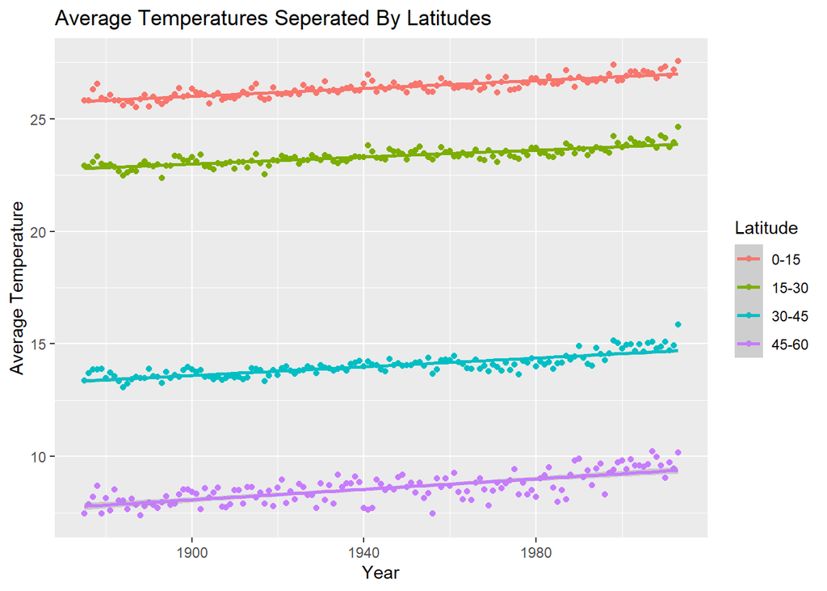

```r
#lm(lat60$averageTemperature~lat60$Year)
## 0.01159

Latitudes <- rbind(lat15, lat30, lat45, lat60)

ggplot(data = Latitudes, aes(Year, averageTemperature, col = Latitude)) +
  geom_point() +
  geom_smooth(method = lm) +
  labs(title = "Average Temperatures Seperated By Latitudes", x = "Year", y = "Average Temperature" )
```

```r
Latitudes <- rbind(lat15, lat30, lat45, lat60)
```

## Part 3

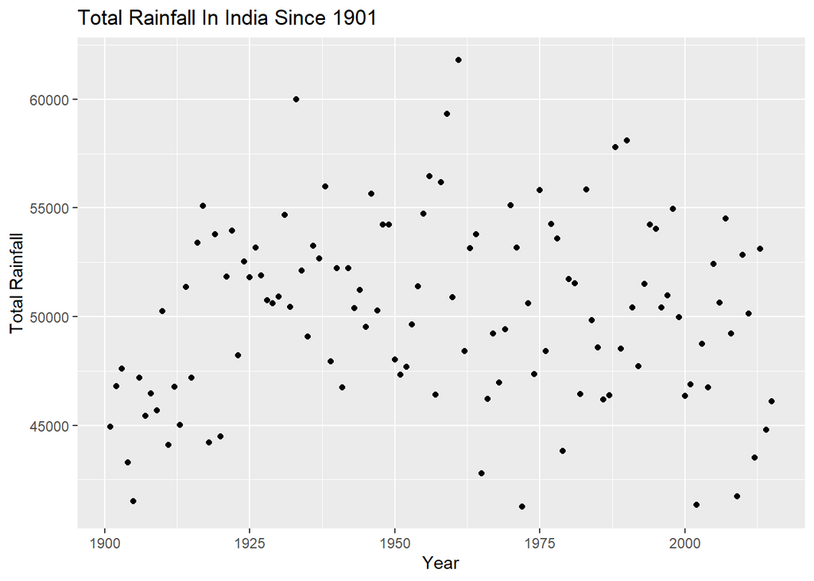

```r
indiaRainfall <- read.csv(file.choose())

Rainfall <- indiaRainfall %>%
  group_by(YEAR) %>%
  summarize(Rainfall = sum(ANNUAL, na.rm = T)) %>%
  arrange(YEAR)

aveRainfall <- indiaRainfall %>%
  group_by(YEAR) %>%
  summarize(averageRainfall = mean(ANNUAL, na.rm = T)) %>%
  arrange(YEAR)

ggplot(Rainfall, aes(x = YEAR, y = Rainfall)) +
  geom_point() +
  labs(title = "Total Rainfall In India Since 1901", x = "Year", y = "Total Rainfall")
```

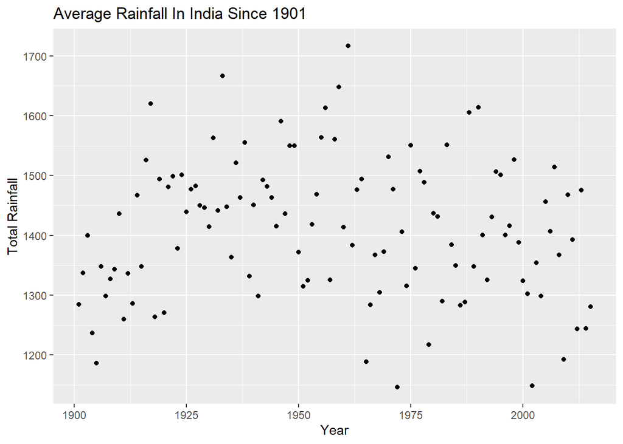

```r
ggplot(aveRainfall, aes(x = YEAR, y = averageRainfall)) +
  geom_point() +
  labs(title = "Average Rainfall In India Since 1901", x = "Year", y = "Total Rainfall")
```

```r
#summary(lm(Rainfall$Rainfall~Rainfall$YEAR))
```

## Bibliography

Masson-Delmotte, V., Zhai, P., Pirani, A., Connors, S. L., Péan, C., Berger, S., Caud, N., Chen, Y., Goldfarb, L., Gomis, M. I., Huang, M., Leitzell, K., Lonnoy, E., Matthews, J. B. R., Maycock, T. K., Waterfield, T., Yelekçi, Ö., Yu, R., & Zhou, B. (Eds.). (2021). Climate Change 2021: The Physical Science Basis. Contribution of Working Group I to the Sixth Assessment Report of the Intergovernmental Panel on Climate Change. Cambridge University Press. https://doi.org/10.1017/9781009157896

Ilangovan, R. (2017, August 5). Rainfall in India. Kaggle. Retrieved October 2, 2022, from https://www.kaggle.com/datasets/rajanand/rainfall-in-india?select=rainfall%2Bin%2Bindia%2B1901-2015.csv